# Midterm Exam 2 - Open Book Section (R) - Part 2

## Instructions

1. Save the .Rmd/.ipnyb file in your working directory - the same directory where you will download the data files into.
2. Read the question and create the code necessary within the code chunk section immediately below each question.
3. Type your answer to the questions in the text block provided immediately after the response prompt.
4. Once you’ve finished answering all questions, knit this file and submit the knitted file *as HTML* on Canvas.

   ```
   * Make sure to start submission of the exam at least 10 minutes before the end of the exam time. It is your responsibility to keep track of your time and submit before the time limit.

   * If you are unable to knit your file as HTML for whatever reason, you may upload your Rmd/ipynb/PDF/Word file instead. However, you will be penalized 15%.

   * If you are unable to upload your exam file for whatever reason, you may IMMEDIATELY attach the file to the exam page as a comment via Grades-> Midterm Exam 2 - Open Book Section - Part 2 -> Comment box.

   * Note that you will be penalized 15% (or more) if the submission is made within 5 minutes after the exam time has expired and a higher penalty if more than 5 minutes. Furthermore, you will receive zero points if the submission is made after 15 minutes of the exam time expiring. We will not allow later submissions or re-taking of the exam.

   * If you upload your file after the exam closes, let the instructors know via a private Piazza post. Please DON'T attach the exam file via a private Piazza post to the instructors since you could compromise the exam process. Any submission received via Piazza will not be considered.

   *#Commented out code will be graded for partial credit and the submitted file must be HTML
   ```

**Ready? Let’s begin.**

### **For questions 1-4: Use the dataset “employee_turnover_prediction”.**

### **For question 5: Use the dataset “quine_dataset”. This dataset was taken from the MASS library.**

## Background

In this exam, you will be considering various attributes to predict **employee turnover** (whether an employee will leave or stay) based on various factors:

1. **Commute Mode:** The mode of transportation the employee uses to commute to work.

   (“Public Transport,” “Car,” “Bike,” “Walk”) **(Qualitative variable)**
2. **Workplace Flexibility:** The level of flexibility the employee has in their work location. (“Remote,” “Hybrid,” “On-Site”) **(Qualitative variable)**
3. **Team Dynamics:** The level of collaboration within the employee’s team. (“High Collaboration,” “Low Collaboration”) **(Qualitative variable)**
4. **Office Location:** The geographical location of the office where the employee works. (“City Center,” “Suburb,” “Rural Area”) **(Qualitative variable)**
5. **Health Benefits:** The type of health benefits provided to the employee by the company. (“Full Coverage,” “Partial Coverage,” “None”) **(Qualitative variable)**
6. **Satisfaction Score:** A rating of the employee’s overall satisfaction with their job.(1-10) **(Quantitative variable)**
7. **Monthly Working Hours:** The total number of hours worked by the employee in a typical month. (120-250) **(Quantitative variable)**
8. **Years With Company:** The number of years the employee has worked at the company. (0.5-35 years)**(Quantitative variable)**
9. **Number of Trainings Attended:** The number of professional development or training sessions the employee has participated in. (0-10) **(Quantitative variable)**
10. **Salary Increase Percentage:** The percentage increase in the employee’s salary over the past year.(0%-20%) **(Quantitative variable)**
11. **Turnover:** Indicates whether the employee left the company. “1” for Turnover (employee left), “0” for No Turnover (employee stayed) **(Response variable)**.

```r
#This seed has been set to 100 to ensure results are reproducible. DO NOT CHANGE THIS SEED
set.seed(100)

#Read the csv file
employee_turnover = read.csv("employee_turnover_prediction.csv", header=TRUE, na.strings = "")

#Remove any potential trailing white space from column names
names(employee_turnover) <- trimws(names(employee_turnover), which = "right")

employee_turnover$Commute_Mode=as.factor(employee_turnover$Commute_Mode)
employee_turnover$Workplace_Flexibility=as.factor(employee_turnover$Workplace_Flexibility)
employee_turnover$Team_Dynamics=as.factor(employee_turnover$Team_Dynamics)
employee_turnover$Office_Location=as.factor(employee_turnover$Office_Location)
employee_turnover$Health_Benefits=as.factor(employee_turnover$Health_Benefits)
employee_turnover$Turnover=factor(employee_turnover$Turnover, levels = c(0, 1))

#Dividing the dataset into training and testing datasets
testRows = sample(nrow(employee_turnover),0.2*nrow(employee_turnover))
testData = employee_turnover[testRows, ]
trainData = employee_turnover[-testRows, ]
row.names(trainData) <- NULL
head(trainData) #display train data
```

```
##       Commute_Mode Workplace_Flexibility      Team_Dynamics Office_Location
## 1              Car                Hybrid  Low Collaboration          Suburb
## 2 Public Transport                Hybrid  Low Collaboration     City Center
## 3              Car                Remote  Low Collaboration     City Center
## 4 Public Transport                Remote High Collaboration          Suburb
## 5             Bike                Remote High Collaboration     City Center
## 6 Public Transport               On-Site High Collaboration     City Center
##    Health_Benefits Job_Satisfaction_Score Monthly_Working_Hours
## 1 Partial Coverage                    3.4                   225
## 2    Full Coverage                    4.7                   231
## 3    Full Coverage                    2.3                   207
## 4    Full Coverage                    7.8                   163
## 5 Partial Coverage                    1.6                   147
## 6    Full Coverage                    8.0                   220
##   Years_With_Company Number_of_Trainings_Attended Salary_Increase_Percentage
## 1               22.9                            3                       14.7
## 2               14.6                            3                       15.8
## 3               34.2                            3                       14.9
## 4                5.1                            9                       18.9
## 5               30.0                            2                       19.0
## 6               29.3                            8                        8.2
##   Turnover
## 1        1
## 2        1
## 3        1
## 4        1
## 5        1
## 6        0
```

## Question 1: Data Exploration (11 points)

**Use the FULL dataset “employee_turnover” for Question 1**

**1a) (2 points) What is the median “Monthly_Working_Hours” for employees across different workplaces?**

*Note*: Answer must be grouped by “Workplace_Flexibility”.

```r
#Code
library(dplyr)
median_hours = aggregate(Monthly_Working_Hours ~ Workplace_Flexibility, data = employee_turnover, FUN = median)
print(median_hours)
```

```
##   Workplace_Flexibility Monthly_Working_Hours
## 1                Hybrid                 186.5
## 2               On-Site                 177.0
## 3                Remote                 184.0
```

**1b) (2 points) What is the proportion of employees who stayed with the company (i.e., did not leave) for each type of “Health_Benefits”?**

*Note*: As an example, the proportion of employees who stayed with the company for Full Coverage equals the number of employees with full coverage who stayed divided by the number of employees with full coverage.

```r
#Code
proportion_stayed = employee_turnover %>%
  group_by(Health_Benefits) %>%
  summarise(stayed_proportion = sum(Turnover==0)/n())
print(proportion_stayed)
```

```
## # A tibble: 3 × 2
##   Health_Benefits  stayed_proportion
##   <fct>                        <dbl>
## 1 Full Coverage                0.478
## 2 None                         0.527
## 3 Partial Coverage             0.540
```

**1c) (2 points) Print the rows with the highest “Salary_Increase_Percentage”. Identify the qualitative variable responses that are the same between the rows with the highest “Salary_Increase_Percentage”?**

```r
#Code
highest_salary_increase = employee_turnover %>%
  filter(Salary_Increase_Percentage == max(Salary_Increase_Percentage))

print(highest_salary_increase)
```

```
##       Commute_Mode Workplace_Flexibility      Team_Dynamics Office_Location
## 1 Public Transport                Remote High Collaboration     City Center
## 2              Car                Hybrid High Collaboration          Suburb
##   Health_Benefits Job_Satisfaction_Score Monthly_Working_Hours
## 1   Full Coverage                    6.2                   133
## 2   Full Coverage                    7.8                   247
##   Years_With_Company Number_of_Trainings_Attended Salary_Increase_Percentage
## 1                5.9                            3                         20
## 2               29.5                            9                         20
##   Turnover
## 1        0
## 2        0
```

**1d) (5 points) Create boxplots and interpret each plot for the following predictors against the response variable (Turnover).**

**i) Monthly_Working_Hours**

**ii) Years_With_Company**

**In general, using boxplots, can we make statements about statistical significance of the differences between the group means? How can we infer if the group means are statistically significantly different from each other?**

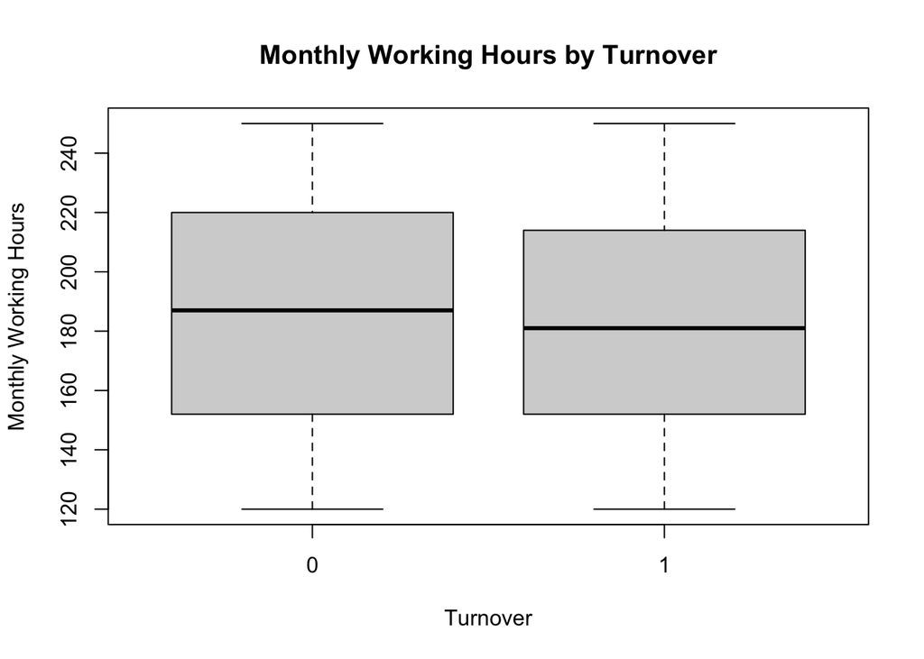

```r
#Code
boxplot(employee_turnover$Monthly_Working_Hours ~ employee_turnover$Turnover,
        main = "Monthly Working Hours by Turnover",
        xlab = "Turnover", ylab = "Monthly Working Hours")
```

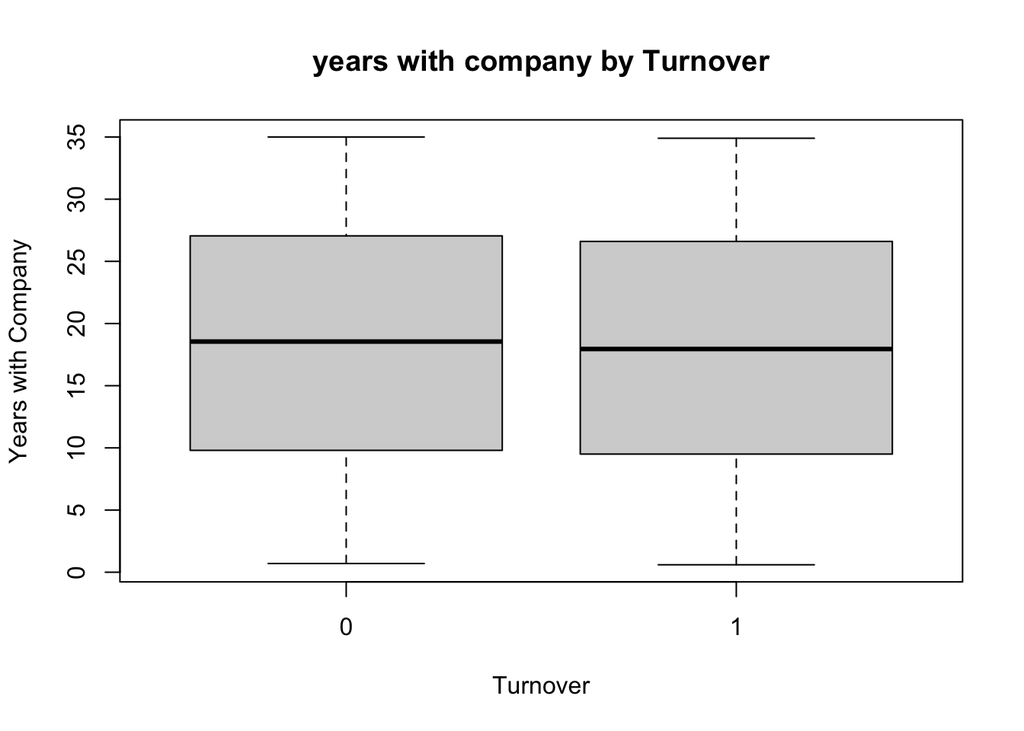

```r
boxplot(employee_turnover$Years_With_Company ~ employee_turnover$Turnover,
        main = "years with company by Turnover",
        xlab = "Turnover", ylab = "Years with Company")
```

**Answer to question 1d**: No, Box plots alone do not allow us to make definitive statements about statistical significance. we infer if the group means are statistically significantly different from each other by using statistal test such as ANOVA, t-test, etc.

## Question 2: Logistic Regression Model (17 points)

**2a) (6 points) In this question, you will fit a reduced model:**

**i) Using the dataset “trainData”, create a logistic regression model (call it “*model1*”) using “Turnover” as the response variable, and Office_Location, Health_Benefits, Monthly_Working_Hours as the predictor variables. (2 points)**

```r
model1 = glm(Turnover ~ Office_Location + Health_Benefits + Monthly_Working_Hours, data = trainData,family = binomial)
summary(model1)
```

```
##
## Call:
## glm(formula = Turnover ~ Office_Location + Health_Benefits +
##     Monthly_Working_Hours, family = binomial, data = trainData)
##
## Coefficients:
##                                  Estimate Std. Error z value Pr(>|z|)
## (Intercept)                      0.492277   0.291671   1.688   0.0915 .
## Office_LocationRural Area       -0.576143   0.218253  -2.640   0.0083 **
## Office_LocationSuburb           -0.017190   0.117217  -0.147   0.8834
## Health_BenefitsNone             -0.182513   0.195211  -0.935   0.3498
## Health_BenefitsPartial Coverage -0.177077   0.128957  -1.373   0.1697
## Monthly_Working_Hours           -0.002089   0.001499  -1.394   0.1634
## ---
## Signif. codes:  0 '***' 0.001 '**' 0.01 '*' 0.05 '.' 0.1 ' ' 1
##
## (Dispersion parameter for binomial family taken to be 1)
##
##     Null deviance: 1792.4  on 1292  degrees of freedom
## Residual deviance: 1781.4  on 1287  degrees of freedom
## AIC: 1793.4
##
## Number of Fisher Scoring iterations: 4
```

**ii) (2 points) Using “model1”, interpret the coefficients of the following predictors below with respect to BOTH the log-odds of turnover and the odds of turnover.**

**1) Monthly working hours 2) Health_BenefitsPartial Coverage.**

**Answer to Question 2a(ii):**

Monthly working hours coefficient is -0.002089

For each additional hour worked per month the log odds of turnover decrease by 0.002089 holding all other variables constant, this is the log odds interpretation. The odds interpretation would be e ^ -0.002089 which equals approximately 0.9979 which means that for each additional hour worked per month the odds of turnover are multiplied by approximately 0.9979

Health_BenefitsPartial coefficient is -0.177077.

**iii) Is the model with all the predictors better at predicting the response than a model with just an intercept term? Explain your reasoning. (2 points)**

*Note*: You can use only the summary output for model1 to answer this question.

**Answer to Question 2a(iii):** If the predictors perfectly predict the response, the model could potentially rely only on an intercept term, but this can lead to overfitting or perfect grouping issues. Regularization or reducing predictors is sometimes necessary to reduce over fitting and improve model stability.

**2b) (4 points) In this question, you will fit the full model:**

**i) (2 points) Using the “trainData” dataset, create a logistic regression model using Turnover as response variable and all variables in “trainData” as predictors (call it model2) and display the summary of model2.**

```r
model2 = glm(Turnover ~ ., data = trainData, family = binomial)
summary(model2)
```

```
##
## Call:
## glm(formula = Turnover ~ ., family = binomial, data = trainData)
##
## Coefficients:
##                                   Estimate Std. Error z value Pr(>|z|)
## (Intercept)                      0.7121742  0.4170846   1.708   0.0877 .
## Commute_ModeCar                 -0.2194221  0.1902054  -1.154   0.2487
## Commute_ModePublic Transport    -0.4588326  0.2010744  -2.282   0.0225 *
## Commute_ModeWalk                -0.3889825  0.2475225  -1.572   0.1161
## Workplace_FlexibilityOn-Site    -0.2499995  0.1549945  -1.613   0.1068
## Workplace_FlexibilityRemote      0.2362574  0.1293537   1.826   0.0678 .
## Team_DynamicsLow Collaboration   0.0299910  0.1233652   0.243   0.8079
## Office_LocationRural Area       -0.5237977  0.2216187  -2.364   0.0181 *
## Office_LocationSuburb           -0.0189136  0.1195890  -0.158   0.8743
## Health_BenefitsNone             -0.1406302  0.1986562  -0.708   0.4790
## Health_BenefitsPartial Coverage -0.1736208  0.1309831  -1.326   0.1850
## Job_Satisfaction_Score           0.0081439  0.0218310   0.373   0.7091
## Monthly_Working_Hours           -0.0018861  0.0015252  -1.237   0.2162
## Years_With_Company              -0.0006824  0.0056727  -0.120   0.9042
## Number_of_Trainings_Attended    -0.0313203  0.0183766  -1.704   0.0883 .
## Salary_Increase_Percentage       0.0108356  0.0102039   1.062   0.2883
## ---
## Signif. codes:  0 '***' 0.001 '**' 0.01 '*' 0.05 '.' 0.1 ' ' 1
##
## (Dispersion parameter for binomial family taken to be 1)
##
##     Null deviance: 1792.4  on 1292  degrees of freedom
## Residual deviance: 1761.4  on 1277  degrees of freedom
## AIC: 1793.4
##
## Number of Fisher Scoring iterations: 4
```

**ii)(2 points) Compare the full logistic regression model (model2) from Question (2bi) against the reduced model (model1) from Question (2ai). What can you conclude from the results of this comparison using a significance level of alpha=0.01?**

```r
anova(model1, model2, test = "Chisq")
```

```
## Analysis of Deviance Table
##
## Model 1: Turnover ~ Office_Location + Health_Benefits + Monthly_Working_Hours
## Model 2: Turnover ~ Commute_Mode + Workplace_Flexibility + Team_Dynamics +
##     Office_Location + Health_Benefits + Job_Satisfaction_Score +
##     Monthly_Working_Hours + Years_With_Company + Number_of_Trainings_Attended +
##     Salary_Increase_Percentage
##   Resid. Df Resid. Dev Df Deviance Pr(>Chi)
## 1      1287     1781.4
## 2      1277     1761.4 10   20.045  0.02883 *
## ---
## Signif. codes:  0 '***' 0.001 '**' 0.01 '*' 0.05 '.' 0.1 ' ' 1
```

**2c) (2 points) Perform a test for overall regression of the logistic regression “model2”, using a significance level of alpha=0.05. Does the overall regression have explanatory power? Provide interpretation of the test.**

```r
anova(model2, test = "Chisq")
```

```
## Analysis of Deviance Table
##
## Model: binomial, link: logit
##
## Response: Turnover
##
## Terms added sequentially (first to last)
##
##
##                              Df Deviance Resid. Df Resid. Dev Pr(>Chi)
## NULL                                          1292     1792.4
## Commute_Mode                  3   7.1800      1289     1785.3 0.066378 .
## Workplace_Flexibility         2   9.9062      1287     1775.3 0.007062 **
## Team_Dynamics                 1   0.0864      1286     1775.3 0.768791
## Office_Location               2   6.3229      1284     1769.0 0.042364 *
## Health_Benefits               2   2.0016      1282     1766.9 0.367583
## Job_Satisfaction_Score        1   0.2303      1281     1766.7 0.631269
## Monthly_Working_Hours         1   1.5272      1280     1765.2 0.216538
## Years_With_Company            1   0.0000      1279     1765.2 0.994505
## Number_of_Trainings_Attended  1   2.6588      1278     1762.5 0.102976
## Salary_Increase_Percentage    1   1.1283      1277     1761.4 0.288138
## ---
## Signif. codes:  0 '***' 0.001 '**' 0.01 '*' 0.05 '.' 0.1 ' ' 1
```

**2d)(5 points) Using “model2”, apply hypothesis testing for a regression coefficient at the 0.01 significance level.**

**i) (1 point) Is the coefficient of “Number_of_Trainings_Attended” statistically significant?**

#**ii) (1 point) State the Null and alternative hypotheses of the test.**

**iii) (1.5 points) Describe the approach we would use to determine the statistical significance of the regression coefficient.**

**iv) (1.5 points) What is the sampling distribution that the test statistic follows?**

**Response to question 2d(ii):** NULL hypothesis for the coefficient for numbers of trainings attended is equal to zero and this would imply that this has no effect on the likelihood of tone over while the alternative hypothesis would be that coefficient for numbers of training attendant is not equal to zero, which means that it has a statistically significant impact on turnover.

**Response to question 2d(iii):** The statistical significance is determined by its P value if the P value is below the chosen significance level (a.k.a. alpha, in this case is 0.01) we would reject the hypothesis hypothesis, concluding that the predictor is statistically significant if it is above, then it is insignificant. **Response to question 2d(iv):** The test Stasik for the coefficient and logistic regression follows a standard normal distribution Z distribution under the no hypothesis therefore, we use the normal Z distribution to calculate the P values.

## Question 3: Decision Tree and Random Forest Models (6 points)

**3a) (4 points) Using the dataset “trainData”, fit the following classification models below using all the predictors in “trainData” and “Turnover” as the response variable.**

**i) Decision Tree Model (call it *model3*).**

**ii) Random Forest Model (call it *model4*).**

**Use metric = “Accuracy”, trControl = trainControl(method=“cv”, number=3) for both models. Display the summary of both models and state the average accuracy for both resampled models.**

```r
library(caret)
# Decision Tree

model3 = train(Turnover ~ ., data = trainData, method = "rpart",
               trControl = trainControl(method="cv", number =3 ))
model3
```

```
## CART
##
## 1293 samples
##   10 predictor
##    2 classes: '0', '1'
##
## No pre-processing
## Resampling: Cross-Validated (3 fold)
## Summary of sample sizes: 862, 862, 862
## Resampling results across tuning parameters:
##
##   cp          Accuracy   Kappa
##   0.02592017  0.5436968  0.08678567
##   0.02643857  0.5436968  0.08678567
##   0.10419907  0.5197216  0.03812272
##
## Accuracy was used to select the optimal model using the largest value.
## The final value used for the model was cp = 0.02643857.
```

```r
# Random Forest

model4 = train(Turnover ~ ., data = trainData, method = "rf",
               trControl = trainControl(method="cv", number =3 ))
model4
```

```
## Random Forest
##
## 1293 samples
##   10 predictor
##    2 classes: '0', '1'
##
## No pre-processing
## Resampling: Cross-Validated (3 fold)
## Summary of sample sizes: 862, 862, 862
## Resampling results across tuning parameters:
##
##   mtry  Accuracy   Kappa
##    2    0.8646558  0.7294986
##    8    0.8917247  0.7834752
##   15    0.8839907  0.7680353
##
## Accuracy was used to select the optimal model using the largest value.
## The final value used for the model was mtry = 8.
```

**3b) (2 points) Which model performed better when comparing the average accuracy of the resampled decision tree and random forest models? Explain the difference between the decision tree model and the random forest model.**

**Answer to Question 3b** random forest, which is model 4 performs better because it improves the ability and accuracy the decision tree model, which is model 3 is simpler and faster to interpret, but is often less accurate because it cannot handle such complex data. The random forest reduces overfitting and variance and combines multiple decision trees leasding to better results.

## Question 4: Prediction (14 points)

**Use the “testData” for all questions in this question.**

**4a)(4 points) Using testData, predict the probability of an employee leaving, i.e. being a turnover, and output the AVERAGE of these probabilities for each of the models below:**

**i) model1 (question 2a) ii) model2 (question 2b) iii) model3 (question 3a) and iv) model4 (question 3a)**

```r
probmodel1 = predict(model1, testData, type = "response")
probmodel2 = predict(model2, testData, type = "response")
probmodel3 = predict(model3, testData, type = "prob")[,2]
probmodel4 = predict(model4, testData, type = "prob")[,2]

#probmodel1
#probmodel2
#probmodel3
#probmodel4

mean_probabilities = data.frame(
  Model1AVGP = mean(probmodel1),
  Model2AVGP = mean(probmodel2),
  Model3AVGP = mean(probmodel3),
  Model4AVGP = mean(probmodel4)

)

print(mean_probabilities)
```

```
##   Model1AVGP Model2AVGP Model3AVGP Model4AVGP
## 1  0.4993429  0.5016798  0.4929429   0.602161
```

**4b) (4 points) Using the probabilities from Q4a and a threshold of 0.5 (inclusive of 0.5), obtain the classifications of an employee being a turnover for all four models.Note: every row in the testData prediction must be classified.Print the last ten classification rows for all the model classifications as well as the actual response for Turnover of those rows.**

```r
CLASSMODEL1 = ifelse(probmodel1 >= 0.5,1,0)
CLASSMODEL2 = ifelse(probmodel2 >= 0.5,1,0)
CLASSMODEL3 = ifelse(probmodel3 >= 0.5,1,0)
CLASSMODEL4 = ifelse(probmodel4 >= 0.5,1,0)

classificationresults = data.frame(
  Actualturnover =testData$Turnover,
  Model1classification = CLASSMODEL1,
  Model2classification = CLASSMODEL2,
  Model3classification = CLASSMODEL3,
  Model4classification = CLASSMODEL4

)

tail(classificationresults,10)
```

```
##      Actualturnover Model1classification Model2classification
## 557               0                    0                    0
## 133               0                    0                    0
## 697               1                    0                    1
## 1050              1                    1                    1
## 1412              1                    1                    1
## 641               0                    0                    0
## 187               1                    1                    1
## 997               1                    1                    1
## 1198              0                    0                    0
## 1256              0                    0                    0
##      Model3classification Model4classification
## 557                     0                    0
## 133                     0                    0
## 697                     0                    0
## 1050                    1                    1
## 1412                    1                    1
## 641                     0                    0
## 187                     0                    1
## 997                     0                    1
## 1198                    0                    0
## 1256                    1                    0
```

4c) (6 points) In this question, you will compare the prediction accuracy of the four models.  
i) (4 points) Using the classifications from Q4b, create a confusion matrix and output the classification evaluation metrics (i.e. Accuracy, Sensitivity, and Specificity) for all four models. Note: every row in the testData classification must be used (do not use only the last ten classification rows).”

**ii) (2 points) Which metric measures the rate of true negatives? Which model shows the highest value for this metric?**

```r
actual = testData$Turnover

confusionmodel1 = confusionMatrix(factor(CLASSMODEL1),factor(actual))
confusionmodel2 = confusionMatrix(factor(CLASSMODEL2),factor(actual))
confusionmodel3 = confusionMatrix(factor(CLASSMODEL3),factor(actual))
confusionmodel4 = confusionMatrix(factor(CLASSMODEL4),factor(actual))

cat("Model 1 metrics: \n")
```

```
## Model 1 metrics:
```

```r
print(confusionmodel1)
```

```
## Confusion Matrix and Statistics
##
##           Reference
## Prediction   0   1
##          0  77  53
##          1  81 112
##
##                Accuracy : 0.5851
##                  95% CI : (0.5293, 0.6394)
##     No Information Rate : 0.5108
##     P-Value [Acc > NIR] : 0.004369
##
##                   Kappa : 0.1668
##
##  Mcnemar's Test P-Value : 0.019677
##
##             Sensitivity : 0.4873
##             Specificity : 0.6788
##          Pos Pred Value : 0.5923
##          Neg Pred Value : 0.5803
##              Prevalence : 0.4892
##          Detection Rate : 0.2384
##    Detection Prevalence : 0.4025
##       Balanced Accuracy : 0.5831
##
##        'Positive' Class : 0
##
```

```r
cat("Model 2 metrics: \n")
```

```
## Model 2 metrics:
```

```r
print(confusionmodel2)
```

```
## Confusion Matrix and Statistics
##
##           Reference
## Prediction   0   1
##          0  89  65
##          1  69 100
##
##                Accuracy : 0.5851
##                  95% CI : (0.5293, 0.6394)
##     No Information Rate : 0.5108
##     P-Value [Acc > NIR] : 0.004369
##
##                   Kappa : 0.1694
##
##  Mcnemar's Test P-Value : 0.795511
##
##             Sensitivity : 0.5633
##             Specificity : 0.6061
##          Pos Pred Value : 0.5779
##          Neg Pred Value : 0.5917
##              Prevalence : 0.4892
##          Detection Rate : 0.2755
##    Detection Prevalence : 0.4768
##       Balanced Accuracy : 0.5847
##
##        'Positive' Class : 0
##
```

```r
cat("Model 3 metrics: \n")
```

```
## Model 3 metrics:
```

```r
print(confusionmodel3)
```

```
## Confusion Matrix and Statistics
##
##           Reference
## Prediction   0   1
##          0 119  97
##          1  39  68
##
##                Accuracy : 0.5789
##                  95% CI : (0.523, 0.6334)
##     No Information Rate : 0.5108
##     P-Value [Acc > NIR] : 0.008242
##
##                   Kappa : 0.164
##
##  Mcnemar's Test P-Value : 1.02e-06
##
##             Sensitivity : 0.7532
##             Specificity : 0.4121
##          Pos Pred Value : 0.5509
##          Neg Pred Value : 0.6355
##              Prevalence : 0.4892
##          Detection Rate : 0.3684
##    Detection Prevalence : 0.6687
##       Balanced Accuracy : 0.5826
##
##        'Positive' Class : 0
##
```

```r
cat("Model 4 metrics: \n")
```

```
## Model 4 metrics:
```

```r
print(confusionmodel4)
```

```
## Confusion Matrix and Statistics
##
##           Reference
## Prediction   0   1
##          0 153  10
##          1   5 155
##
##                Accuracy : 0.9536
##                  95% CI : (0.9246, 0.9738)
##     No Information Rate : 0.5108
##     P-Value [Acc > NIR] : <2e-16
##
##                   Kappa : 0.9071
##
##  Mcnemar's Test P-Value : 0.3017
##
##             Sensitivity : 0.9684
##             Specificity : 0.9394
##          Pos Pred Value : 0.9387
##          Neg Pred Value : 0.9688
##              Prevalence : 0.4892
##          Detection Rate : 0.4737
##    Detection Prevalence : 0.5046
##       Balanced Accuracy : 0.9539
##
##        'Positive' Class : 0
##
```

**Response to question 4c(ii) :** Specificity measures the rate of true negatives and model 4 shows the highest value for this metric at 0.9394.

## Question 5: Poisson Regression Model (12 points)

**Use the “quine_dataset” for Question 5.**

### Background

This data frame contains the following columns:

**`Eth`**

ethnic background: Aboriginal or Not, (`"A"` or `"N"`).

**`Sex`**

sex: factor with levels (`"F"` or `"M"`).

**`Age`**

age group: Primary (`"F0"`), or forms `"F1,"` `"F2"` or `"F3"`.

- **F0**: Primary school age (youngest children)
- **F1**: First-year high school (Form 1)
- **F2**: Second-year high school (Form 2)
- **F3**: Third-year high school (Form 3)

**`Lrn`**

learner status: factor with levels Average (“AL”) or Slow learner (“SL”)

**`Days`**

days absent from school in the year.

```r
# Read data
quine_dataset = read.csv("quine_dataset.csv", header=TRUE, na.strings = "")

# Remove any potential trailing white space from column names
names(quine_dataset) <- trimws(names(quine_dataset), which = "right")

# Show first few rows
head(quine_dataset)
```

```
##   Eth Sex Age Lrn Days
## 1   A   M  F0  SL    2
## 2   A   M  F0  SL   11
## 3   A   M  F0  SL   14
## 4   A   M  F0  AL    5
## 5   A   M  F0  AL    5
## 6   A   M  F0  AL   13
```

**5a) (4 points)**

**i)(2 points) Plot a histogram of the count of “Days” from the “quine_dataset”**

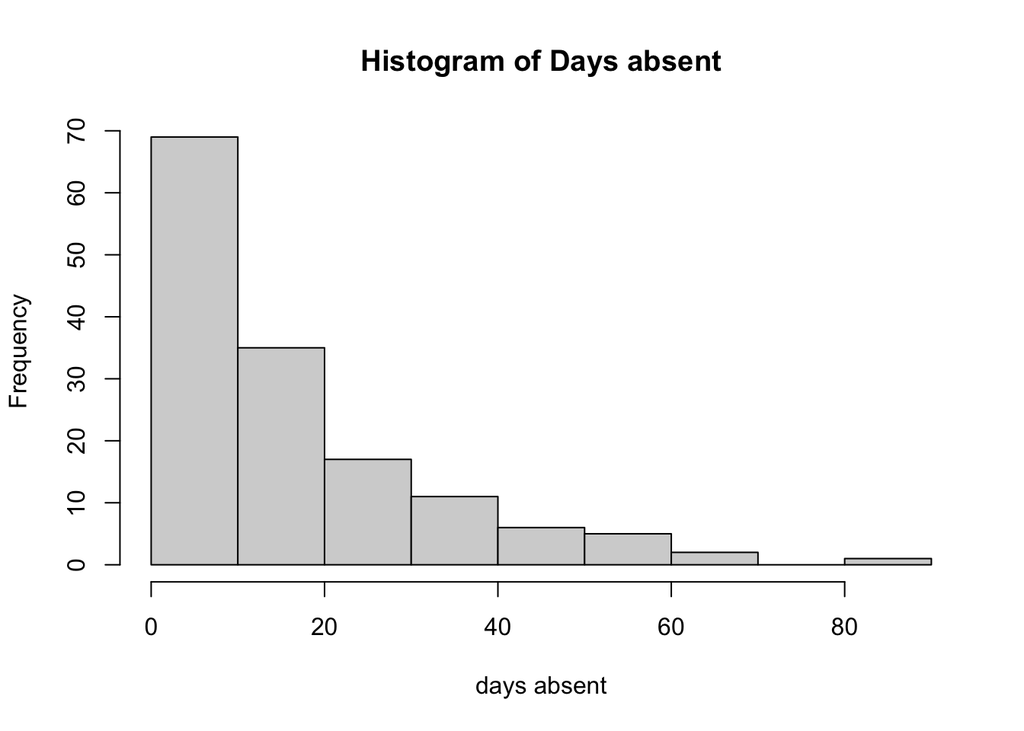

```r
# Check the distribution of the response, Days
 hist(quine_dataset$Days, main = "Histogram of Days absent", xlab= "days absent")
```

**ii)(2 points) Create boxplots of the response variable “Days” against the predicting variable “Sex”. Explain the relationship between the response variable and predicting variable based on the boxplot. Using the boxplot only, do you observe any overlap or potential outliers?**

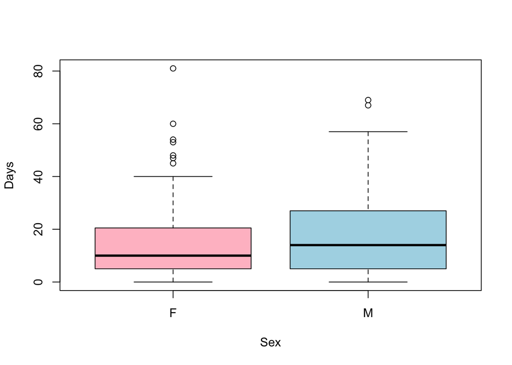

```r
#Code

boxplot(Days ~ Sex, data = quine_dataset, Main = "Days absent by sex", col=c("pink", "lightblue"))
```

**Response to Q5a(ii)** Based on the box pot males have a higher average amount of absence days compared to females while females have a higher amount of outliers compared to males.

5b) (4 points)  
i) Fit a poisson regression model using all the predictors from the “quine_dataset” and “Days” as the response variable. Call it pois_model1 and display the model summary

**ii) Interpret the coefficient of “AgeF2” in pois_model1 with respect to the log expected “Days”.**

**iii) Interpret the coefficient of “EthN” in pois_model1 with respect to the rate ratio of “Days”.**

**iv) Why can’t we use a standard regression model with the log transformation of the response variable instead of creating a Poisson regression model?**

```r
pois_model1 = glm(Days ~ ., family = poisson, data = quine_dataset)
summary(pois_model1)
```

```
##
## Call:
## glm(formula = Days ~ ., family = poisson, data = quine_dataset)
##
## Coefficients:
##             Estimate Std. Error z value Pr(>|z|)
## (Intercept)  2.71538    0.06468  41.980  < 2e-16 ***
## EthN        -0.53360    0.04188 -12.740  < 2e-16 ***
## SexM         0.16160    0.04253   3.799 0.000145 ***
## AgeF1       -0.33390    0.07009  -4.764 1.90e-06 ***
## AgeF2        0.25783    0.06242   4.131 3.62e-05 ***
## AgeF3        0.42769    0.06769   6.319 2.64e-10 ***
## LrnSL        0.34894    0.05204   6.705 2.02e-11 ***
## ---
## Signif. codes:  0 '***' 0.001 '**' 0.01 '*' 0.05 '.' 0.1 ' ' 1
##
## (Dispersion parameter for poisson family taken to be 1)
##
##     Null deviance: 2073.5  on 145  degrees of freedom
## Residual deviance: 1696.7  on 139  degrees of freedom
## AIC: 2299.2
##
## Number of Fisher Scoring iterations: 5
```

**Response to question 5b(ii):** The coefficient for AgeF2 in the poisson regression model1 is 0.25783. This coefficient explains the expected difference in absence days for students in this age group compared to the baseline. Since the coefficient is positive, this means that being in the AgeF2 group is associated with an increase in the log of expected numbers of days absent.

**Response to question 5b(iii):** The coefficient of ethnicity in model1 is -0.53360 which means that being in this group is associated with the decrease in the expected numbers of day being absent.

**Response to question 5b(iv):** Poisson regression is ideal compared to standard regression Models with the log transformation because it is ideal for count data as it models non-negative discrete outcomes and it accounts for mean and variance relationships within the data.

**5c)(4 points)**

**i) Calculate the estimated dispersion parameter for “pois_model1” using both the deviance and Pearson residuals. Is this an overdispersed model using a threshold of 2.0? Justify your answer.**

**ii) Create a proposed model (call it “pois_model2”) that handles overdispersion using the quine_dataset.**

**iii) Explain the concept of overdispersion in Poisson regression and discuss the potential causes of overdispersion.**

**iv) Describe how overdispersion can affect the reliability of statistical inference in Poisson regression models.**

```r
deviancedispersion = deviance(pois_model1)/ df.residual(pois_model1)
pearsondispersion = sum(residuals(pois_model1, type = "pearson")^2) / df.residual(pois_model1)

cat("Dispersion(Deviance):",deviancedispersion, "\n")
```

```
## Dispersion(Deviance): 12.20652
```

```r
cat("Dispersion(Pearson):",pearsondispersion, "\n")
```

```
## Dispersion(Pearson): 13.16684
```

**Response to Q5c(i)** Since both dispersion parameters are greater than 2, the model is over disperse, which means that the poisson model may not be a good fit

Dispersion(Deviance): 12.20652 Dispersion(Pearson): 13.16684

**Response to Q5c(ii)**

```r
pois_model2 = glm(Days ~ ., family = quasipoisson, data = quine_dataset)
summary(pois_model2)
```

```
##
## Call:
## glm(formula = Days ~ ., family = quasipoisson, data = quine_dataset)
##
## Coefficients:
##             Estimate Std. Error t value Pr(>|t|)
## (Intercept)   2.7154     0.2347  11.569  < 2e-16 ***
## EthN         -0.5336     0.1520  -3.511 0.000602 ***
## SexM          0.1616     0.1543   1.047 0.296914
## AgeF1        -0.3339     0.2543  -1.313 0.191413
## AgeF2         0.2578     0.2265   1.138 0.256938
## AgeF3         0.4277     0.2456   1.741 0.083831 .
## LrnSL         0.3489     0.1888   1.848 0.066760 .
## ---
## Signif. codes:  0 '***' 0.001 '**' 0.01 '*' 0.05 '.' 0.1 ' ' 1
##
## (Dispersion parameter for quasipoisson family taken to be 13.16691)
##
##     Null deviance: 2073.5  on 145  degrees of freedom
## Residual deviance: 1696.7  on 139  degrees of freedom
## AIC: NA
##
## Number of Fisher Scoring iterations: 5
```

**Response to Q5c(iii)** Over dispersion happens when the variance of the response variable is bigger than the mean, which does not confine to the Poisson assumption that mean = variance

**Response to Q5c(iv)** Overdispersion can affect the statistical inference in poisson regression models because it can lead to test statistics being too large and P values being too small. This can make us assume that certain predictors are significant when they truly are not :) **End of exam**